# Euro 2020

Cosa c’è dietro al risultato?

Marco Gherbezza

# Introduzione

Come tutti noi ricorderemo il 2021 è stato l’anno dell’Italia un po’ in tutti i campi. Abbiamo trionfato nel campo musicale grazie alla vittoria all’Eurovision da parte dei Måneskin, abbiamo avuto un grosso riconoscimento anche in campo fisico in quanto Giorgio Parisi (assieme ad altri 2 fisici stranieri) ha vinto il Nobel per la fisica per il contributo alla comprensione dei sistemi fisici complessi, anche in ambito artistico abbiamo avuto un gran successo essendoci stati diversi film nominati ai Golden Globe e Laura Pausini premiata come miglior canzone originale. I successi più evidenti però, sono arrivati in ambito sportivo in quanto abbiamo vinto diversi ori olimpici (tra cui i 100 metri con Marcel Jacobs e il salto in alto con Gianmarco Tamberi), raggiunto la finale del torneo di tennis di Wimbledon con Matteo Berrettini e soprattutto, ultimo ma non per importanza, l’europeo di calcio che ha fatto emozionare anche a chi del pallone non interessa.

Molto spesso però ci si sofferma solamente sul risultato e non sul percorso fatto per arrivarci. Da appassionato di dati e di calcio vorrei quindi proporvi una mia analisi sull’europeo andando a snocciolare un po’ di curiosità sulle nazionali che hanno partecipato e sul modo in cui lo hanno fatto, per capire se l’Italia abbia vinto perchè ha avuto una proposta di calcio migliore o per altri motivi.

## Differenza di età per reparti

Per curiosità dò un occhiata al grafico raffigurante la divisione per ruolo dei giocatori, basandomi sulla loro età e scopro che:

- I ruoli in cui serve più esperienza sono quelli difensivi in cui si può anche giocare più a lungo come ad esempio si può pensare ad una leggenda nostrana come può essere Gianluigi Buffon.
- Si può notare anche che i giocatori più giovani presenti al torneo sono prevalentemente centrocampisti e difensori.

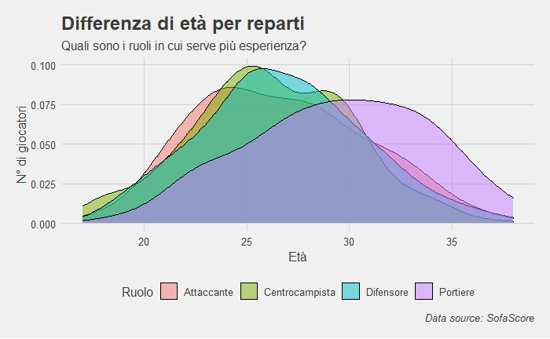

### Quali sono i campionati più rappresentati agli scorsi europei?

| Campionato | n |
| --- | --- |
| Premier League | 137 |
| Bundesliga | 91 |
| Serie A | 52 |
| LaLiga | 41 |
| English Championship | 33 |
| Premier Liga | 32 |
| Ligue 1 | 26 |
| Serie A | 22 |
| Eredivisie | 17 |
| NB 1 | 17 |

- Come ci si poteva aspettare i primi 4 posti sono occupati dai 4 campionati europei più seguiti dai telespettatori;
- Soprendentemente invece al quinto e sesto posto troviamo la seconda lega inglese (Championship) e ed il campionato russo che mettono dietro il più quotato campionato francese.

### Quali sono i club che hanno portato più giocatori a rappresentare le proprie nazionali all’Europeo?

| Squadra | n |
| --- | --- |
| Chelsea | 16 |
| Manchester City | 15 |
| Bayern Monaco | 14 |
| Juventus | 12 |
| Dynamo Kyiv | 11 |
| Borussia Dortmund | 10 |
| Leipzig | 10 |
| Manchester United | 10 |
| Atalanta | 9 |
| Borussia Mönchengladbach | 9 |

Possiamo notare che nelle prime due posizioni troviamo Chelsea e Manchester City, ossia le finaliste della competizione europea più importante, la Champions League. Successivamente troviamo due grandi potenze del calcio europeo come Bayern Monaco e Juventus, mentre scendendo ancora troviamo il Borussia Dortmund e soprendentemente due squadre meno blasonate come Dinamo Kyiv e Leipzig.

## 3 possibili spunti

- Il possesso palla è essenziale?
- Chi ha creato di più ha anche raccolto di più?
- Portiere più determinante?

## Migliore differenza reti?

Qual è la squadra che ha un miglior bilancio tra goal segnati e goal presi?

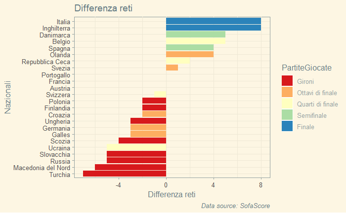

Come ci si poteva aspettare il grafico evidenzia l’importanza di aver una buona differenza reti per poter progradire nel torneo. Questo spiega quindi la divisione netta tra le squadre che hanno disputato solamente la fase a gironi e quelle che hanno disputato anche la fase ad eliminazione diretta. Ci sono però delle situazioni più ambigue come ad esempio l’Ucraina che, nonostante abbia subito molti più goal di quelli prodotti, è arrivata a giocarsi i quarti di finale mentre l’Olanda nonostante abbia avuto una segnato molti più goal rispetto a quelli concessi abbia potuto raggiungere solamente gli ottavi di finale della competizione. Un motivo per il quale succedono queste situazioni sta nel fatto che, nella fase gironi c’è più libertà nel giocare in quanto c’è più margine d’errore, la qualità delle rose molto spesso non è equa e per questo sono più probabili partite con molti goal, mentre nella fase ad eliminazione diretta essendoci in gioco la possibilità di proseguire nel torneo le partite sono molto tirate anche perchè le squadre con meno qualità possono pensare di giocare rinchiudendosi in difesa cercando di segnare in contropiedi per cercare di colmare il gap qualitativo e questo diminuisce la possibiltà di goleade.

## Tanto possesso palla = tanti goal?

Il possesso palla, visto in questo caso come il numero di tocchi palla, è mediamente utile per fare goal e progredire nel torneo? Come in tutte le cose, anche nel calcio ci sono stati molti cambiamenti negli ultimi ventanni, si è passati da un calcio più povero e passionale ad uno sport più atletico e forse un po’ più legato al soldo. Una delle novità maggiori degli ultimi anni sul palcoscenico mondiale è stato soprattuto l’idea di vincere le partite attraverso il dominio territoriale del campo attraverso il possesso palla portato in voga dal cosiddetto Tiki-Taka dell’iconico Barcellona di Guardiola. Gli spagnoli sono stati sempre esperti nel possesso palla e nell’affrontare le partite puntando a dominarle attraverso il bel gioco, ma grazie all’espressione calcistica della squadra della Catalunya questo modo di giocare è stato portato agli occhi di tutti influenzando gli altri club e dividendo l’opinione pubblica. L’opione pubblica è divisa in quanto una fetta preferisce vedere la propria squadra giocare in modo più difensivo cercando di non prendere goal e di segnare in contropiede (il catenaccio, comunemente associato al calcio all’italiana) mentre ad altri piace di più vedere la propria squadra più propositiva e sempre con il pallino del gioco. Andiamo quindi a vedere cosa ci dicono i dati.

[figure not shown]

Come si può vedere dal grafico c’è una relazione lineare tra il possesso palla ed i goal segnati, si può anche notare che la maggior parte delle squadre che hanno terminato il loro torneo ai gironi abbiano avuto un basso numero medio di palloni toccati, probabilmente influenzato anche dalla minor qualità dei propri interpreti. Ci sono inoltre due outliner come Danimarca e Finlandia, la prima è stata più pratica e cinica a segnare più goal avendo meno palloni toccati per costruire gioco mentre i finnici hanno cercato di costuire di più ma non sono riusciti a convertire in goal questi palloni toccati.

## Quanto conta avere un possesso di qualità?

Il possesso palla può essere utile in quanto essendo in controllo della palla non puoi essere in difficoltà come quando il possesso lo hanno gli avversari ma il solo possesso è nulla senza la qualità nei passaggi che ti porta a concretizzare il controllo territoriale. Proviamo quindi a vedere se le squadre con più possesso sono qualitative oppure se sono più distratte.

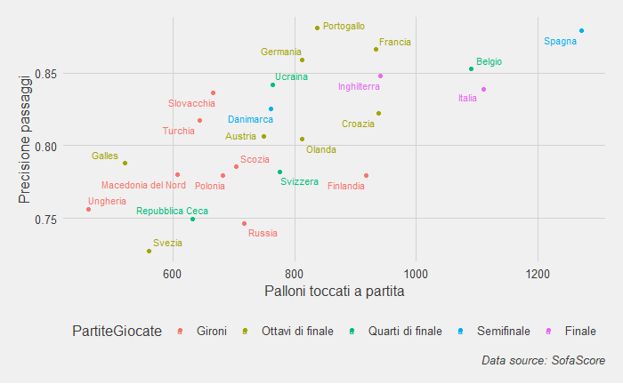

## Possesso palla per reparti

Proviamo ora ad approfondire la nostra visione sulla qualità del possesso di palla delle nazionali andando ad analizzare come hanno contribuiti i tre reparti di movimento (difensori, centrocampisti, attaccanti) ad esso.

### Come hanno gestito il possesso le varie nazionali?

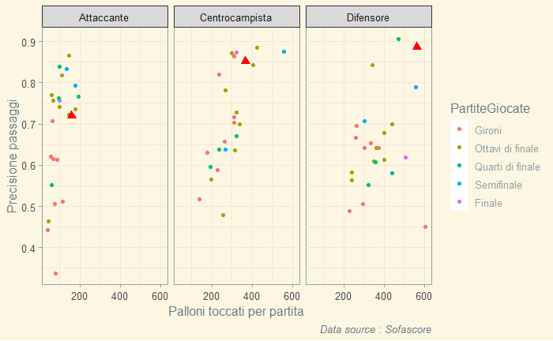

Come si può notare dal grafico e come ci si poteva aspettare, gli attaccanti giocano molti meno palloni dei difensore e dei centrocampisti in quanto giocando la maggior parte del tempo marcato, o comunque nella metà campo avversario hanno più difficoltà ad entrare attivamente nel gioco e nel possesso della squadra.

### Nella propria meta campo …

Osserviamo ora la qualità del possesso che hanno proposto le nazionali nella propria metà campo.

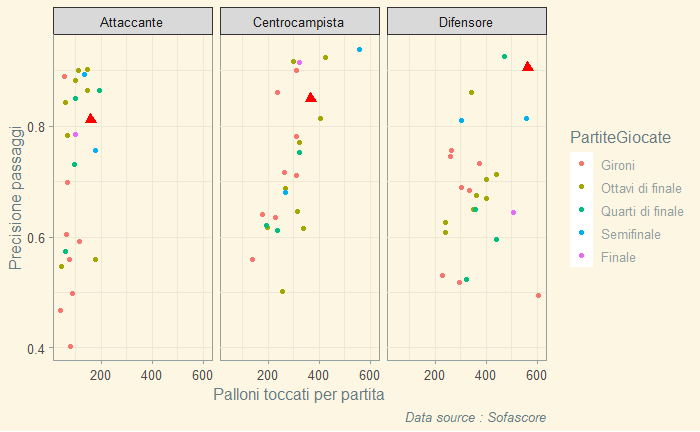

Come si può notare dal grafico il possesso il possesso palla della compagine italiana è stato di buon livello nella propria metà campo per tutti i reparti, spicca soprattutto la prestazione della difesa la quale è la migliore nel rapporti palloni toccati/precisione passaggi. Sicuramente questa qualità di palleggio ha aiutato a diminuire le possibilità di farci male da parte degli avversari.

Osservando il grafico, non si può notare una relazione lineare tra possesso di qualita ed avanzamento nel torneo.

### … e nella metà campo avversaria?

Ora invece andiamo a dare un occhiata al possesso nella metà campo avversaria, ossia dove generalmente è più difficile avere qualità essendo molto spesso pressati dagli avversari.

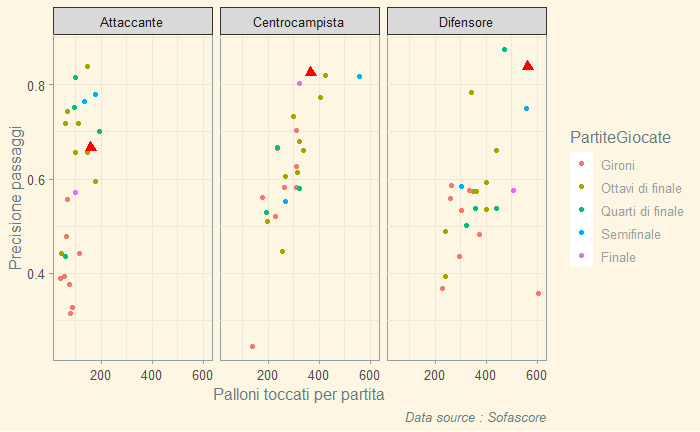

Anche in questo caso non si può notare una relazione lineare tra possesso di qualita ed avanzamento nel torneo.

## Chi ha raccolto meno di quanto creato?

Dopo aver esaminato il posesso palla e la sua relazione con i goal segnati da ogni squadra, cerchiamo di capire quali sono le nazionali che hanno sprecato più occasioni da goal.

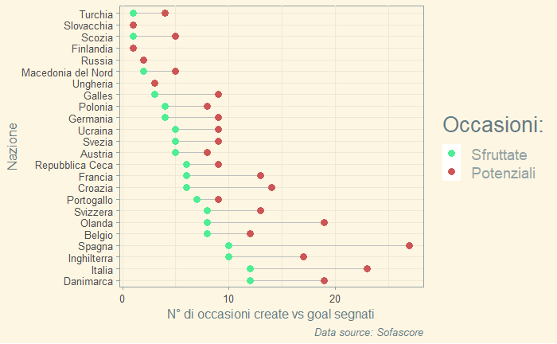

Come si può osservare dal grafico soprastante le squadre che hanno concretizzato meno rispetto al volume di occasioni create sono la spagna, che come abbiamo visto nei grafici precedenti è stata anche la squadra con un miglior possesso palla qualitativo e ciò ricorda che nel calcio si vince segnando un goal in più dell’avversario e non avendo solamente il possesso di palla, seguita da Olanda ed Italia, anch’essa produttrice di un possesso di palla molto qualitativo.

## Quale reparto ha contribuito con più goal?

Andiamo ad analizzare da vicino le 5 nazionali che hanno marcato più goal nel torneo provando a capire quale reparto ha contribuito di piu.

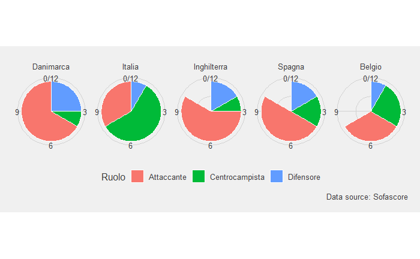

Possiamo dunque notare che anche in questo caso non c’è una legge certa. Ci saremmo potuti aspettare certamente che gli attaccanti avessero trascinato le proprie nazionali a suon di goal ma, come vediamo nel secondo grafico a torta la nostra nazionale ha mandato in goal prevalentemente i nostri centrocampisti i quali probabilmente hanno sfruttato il buon possesso palla della nostra nazionale per degli inserimenti pericolosi in area di rigore. Possiamo notare anche come la Danimarca oltre ad essere stata trascinata dai suoi attaccanti ha mandato in rete molto i suoi difensori, probabilmente abili nel gioco aereo sfruttando le palle da fermo.

## Dribblare è essenziale per segnare?

Un altro elemento fondamentale e spettacolare del calcio sono i dribbling che permettono i giocatori di sorpassare l’avversario creando molti grattacapi alla squadra difendente che si troverà, sul momento, con un uomo in meno a difendere. Molte volte i dribling sono spettacolare da vedere in quanto sono un elemento inaspettato per lo spettatore in quanto possono avvenire in svariati modi ma, oltre all’aspetto scenico, hanno anche una fort e utilita. Proviamo quindi a capire quali sono le squadre che ne fanno più utilizzo e chi invece preferisce arrivare al goal attraverso una rete di passaggi.

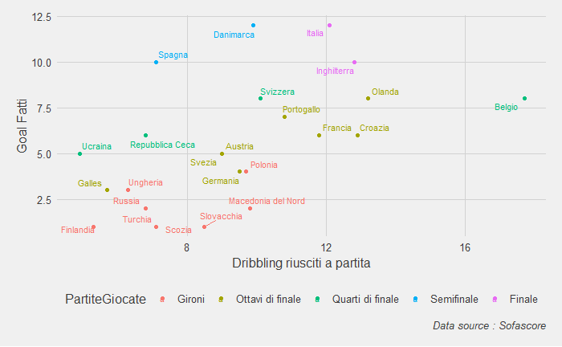

Come si può capire dal grafico, i dribbling non sono essenziali per segnare ma sono uno strumento che potrebbe essere utilizzato a discrezione del piano di gioco utilizzato dalla squadra. Si può notare come il Belgio sia di gran lunga la squadra che ne fa più utilizzo, seguita da Olanda e Croazia (le quali probabilmente si affidano ai dribbling per sopperire al longo possesso non molto qualitativo). Possiamo inoltre osservare come le due finaliste, Italia e Inghilterra, abbiano un dribbling riusciti simili mentre si può notare come la Spagna preferisca affidarsi prevalentemente al possesso qualitativo rispetto ai dribbling.

# Analizzo il contributo dei reparti

Dopo aver dato un occhaiata alle caratteristiche delle verie nazionali, andiamo un po’ più in profondità cercando di analizzare come si sono comportati i settori (ossia portieri, difensori, centrocampisti ed attaccanti) di esse per capire se ci sono differenze e punti di forza che hanno aiutato a raggiungere una determinata dfase del torneo.

## Portieri

Iniziamo andando ad osservare probabilmente il ruolo più delicato in una squadra calcistica, ossia quello del portiere. Il portiere spesso è elogiato per le proprie parate ed i salvataggi che esegue per non far segnare la squadra avversaria ma è anche additato come colpevole ogni volta che ne subisce uno.

### Goal subiti vs Salvataggi a partita

Come primo sguardo andiamo ad osservare quale portiere ha compiuto più parate in confronto ai goal subiti.

[figure not shown]

La prima cosa che chiama la nostra attenzione è la presenza di una doppia pallina per quanto riguarda la nazionale russa. Ovviamente ciò significa l’utilizzo di due portieri, osservando il grafico si può ipotizzare che la scelta sia stata dettata dai 3 goal presi e dalle poche parate del portiere rappresentato dal punto in basso a destra.

Possiamo inoltre notare che più una nazionale è arrivata lontano nel torneo meno (mediamente) il portiere è stato chiamato in causa. Si può notare inoltre la gran performance del portiere finlandese il quale ha eseguito molte parate per partita subendo una media di un solo goal a partita.

## Difensori

Passiamo dunque ad analizzare il reparto difensivo, il cui compito principale è ostacolare la squadra avversaria per non farle segnare goal ed anche impostare l’azione offensiva.

### Possessi persi

Come abbiamo visto nell’introduzione ci sono essenzilamente due grandi filosofie nel calcio: il catenaccio (che è più pratico e punta al prendere un goal meno dell’avversario) e il calcio offensivo (che è più propenso al segnare un goal più dell’avversario). Queste due filosofie portano il reparto difensivo anche a rischi diversi: in quanto la prima vuole che il pallone rimanga essenzialmente in possesso della squadra avversaria e quindi spinge i difensori a rischiare meno passaggi mentre la seconda, vedendo il reparto difensivo come la sorgente della propria costruzione del gioco, porta i difensori a rischiare più passaggi e quindi a prendersi più rischi in fase di costruzione. Andiamo quindi a vedere cosa ci suggeriscono i dati sulla visione delle varie nazionali.

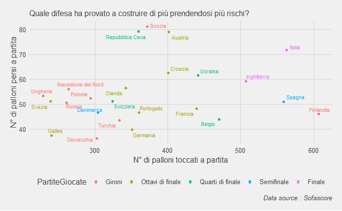

### Intercettazioni vs contrasti

Ora proviamo a vedere come si sono comportate le difese nel loro funzione naturale, ossia il difendere. Due dei modi per interrompere il possesso avversario sono le intercettazioni, ossia quando un giocatore entra in possesso della palla interrompendo un passaggio avversario, ed i contrasti, ossia il tentativo da parte di un giocatore difendente di recuperare palla quando un avversario ne è in possesso.

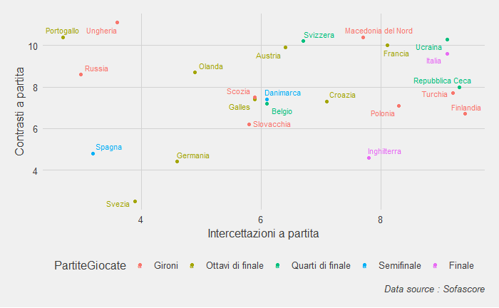

Anche in questo caso c’è molta varieta, uno spunto interessante ce lo da la Spagna la quale, essendo una della squadre con il magggior numero di palloni toccati ed una ottima percentuale di passaggi riusciti, ci fa pensare che si può ovviare alla difesa “tradizionale”, composta da contrasti duri per recuperare la palla, tenendo il possesso del gioco. Rimanendo in possesso del pallone tolgono quindi la possibilità agli avversari di creargli grattacapi. Diversa può essere invece la Svezia la quale non ha un buon possesso palla ma nonostante questo abbia fatto pochi intercetti e contrasti

## Centrocampisti

Continuiamo il nostro percorso tra i reparti delle squadre andando ad analizzare il centrocampo, ossia il cuore delle squadre. Il centrocampo è forse il ruolo alla quale viene chiesto di svolgere più ruoli, sia in fase offensiva che in fase offensiva trovandosi al centro del gioco sempre.

### Centrocampo più creativo?

Iniziamo analizzando la fantasia dei centrocampi guardando alle occasioni create rispetto al volume di palloni giocati. Essendo sempre a supporto degli attaccanti teoricamente i centrocampisti sono i più adatti a creare occasioni da goal facendo passaggi in profondità o creando situazioni favorevoli ai loro finalizzatori.

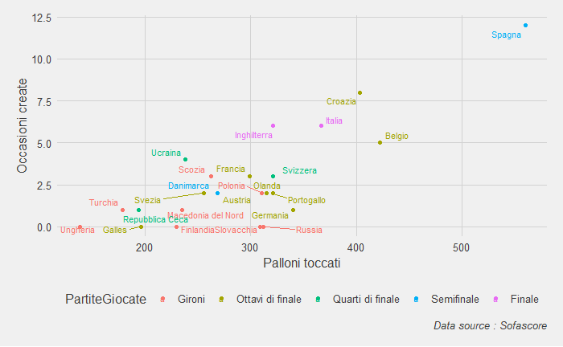

Come possiamo vedere dal grafico anche in questo caso la Spagna è al primo posto per quanto riguarda le occasioni create dai centrocampisti rispetto al volume di palloni toccati, probabilmente aiutati dal loro possesso di palla molto qualitativo. Subito sotto troviamo la Croazia ed il Belgio che come abbiamo visto precedentemente è anche la squadra con più dribbling riusciti.

### Quale centrocampo ha rischiato di più?

Dopo aver analizzato la creatività proviamo a vedere, invece, come hanno gestito il loro possesso palla. Se abbiano avuto un possesso di qualità o se invece sono stati molti i possessi persi dai centrocampi delle varie nazionali.

[figure not shown]

Anche in questo caso la Spagna è una spanna sopra alle sue contendenti in quanto avendo un volume di palloni toccati elevato è naturale avere anche un numero maggiore di possessi persi, nonostante l’elevata percantuale di passaggi corretti. Come visto precedentemente il centrocampo della compagine iberica viene seguito da quello belga e croato

## Attaccanti

Finiamo il nostro percorso tra i reparti andando ad osservare il lovoro svolto dai reparti offensivi delle varie squadre ai quali viene affidato prevalentemente il compito di finalizzare le azioni offensive oppure di fare da boa, ossia mantenere il possesso di palla dopo i lanci lunghi dalla difesa in modo da far salire la squadra.

### Quale attacco ha avuto bisogno di più tiri per segnare ?

In quanto il compito naturale degli attaccanti è quello di concretizzare le sortite offensive delle proprie squadre andiamo ad osservare quali sono stati gli attacchi più cinici, ossia i quali hanno avuto bisogno di meno tiri per segnare.

[figure not shown]